# Cvičenie 3: AR(p) model, stacionarita a Woldova reprezentácia

Výpočty v R-ku z hodiny

# Príklad 1: Woldova reprezentácia

Daný proces: $x_t = 5 - 0.4x_{t-1} + 0.1x_{t-2} + u_t$.

Analytické riešenie (explicitný predpis odvodený na hodine):

```r
k <- 1:5
(1/2 + sqrt(14)/14) * (-0.2 - sqrt(0.14))^k + (1/2 - sqrt(14)/14) * (-0.2 + sqrt(0.14))^k
```

```
## [1] -0.40000  0.26000 -0.14400  0.08360 -0.04784
```

Na kontrolu Woldova reprezentácia z R-ka:

```r
ARMAtoMA(ar = c(-0.4, 0.1), lag.max = 5)
```

```
## [1] -0.40000  0.26000 -0.14400  0.08360 -0.04784
```

# Príklad 2: Woldova reprezentácia

Daný proces $x_t = 5 + 0.4x_{t-1} - 0.1x_{t-2} + u_t$.

Analytické riešenie (explicitný predpis odvodený na hodine):

```r
phi <- atan(sqrt(6)/2)
r <- sqrt(10)/10
r^k * (cos(k*phi) + 0.2/sqrt(0.06) * sin(k*phi))
```

```
## [1]  0.40000  0.06000 -0.01600 -0.01240 -0.00336
```

Na kontrolu Woldova reprezentácia z R-ka:

```r
ARMAtoMA(ar = c(0.4, -0.1), lag.max = 5)
```

```
## [1]  0.40000  0.06000 -0.01600 -0.01240 -0.00336
```

# Príklad 3: Stacionarita procesov

### Proces $(1+0.3L+0.2L^2)x_t = 5+u_t$

```r
abs(polyroot(c(1,0.3, 0.2)))
```

```
## [1] 2.236068 2.236068
```

Znázornime korene v komplexnej rovine spolu s jednotkovým kruhom.

Užitočné funkcie a parametre:

- ak dostne `plot` ako vstup komplexné čísla, nakreslí na x-ovú os ich reálnu a na y-ovú os imaginárnu časť
- parameter `asp = 1` zabezpečí rovnakú mierku na obidvoch osiach
- funkcia `curve` nakreslí zadanú krivku pre zadaný rozsah nezávislej premennej, s parameterom `add = TRUE` ju dokreslí do pôvodného obrázku
- osi môžeme kresliť pomocou `abline` (horizontálnu s parametrom `h`, vertikálnu s parametrom `v`)

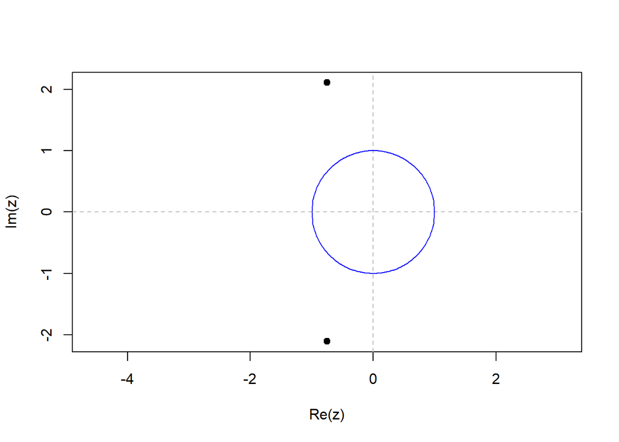

```r
# Vypočítame koreňe polynómu a vykreslíme ich
z <- polyroot(c(1,0.3,0.2))
plot(z, asp  = 1, pch = 19)

# Pridáme šedé čiary pre osi
abline(h = 0, col = "grey", lty = 2)
abline(v = 0, col = "grey", lty = 2)

# Pridáme krivku pre jednotkový kruh
curve(sqrt(1 - x^2), from = -1, to = 1, add = TRUE, col = "blue")
curve(-sqrt(1 - x^2), from = -1, to = 1, add = TRUE, col = "blue")
```

Oba korene v absolútnej hodnote väčšie ako 1 (t. j. ležia mimo jednotkového kruhu). Proces je stacionárny.

### Proces $(1-0.25L+0.6L^2-0.55L^3)x_t = u_t$

```r
abs(polyroot(c(1,-0.25,0.6,-0.55)))
```

```
## [1] 1.082193 1.082193 1.552488
```

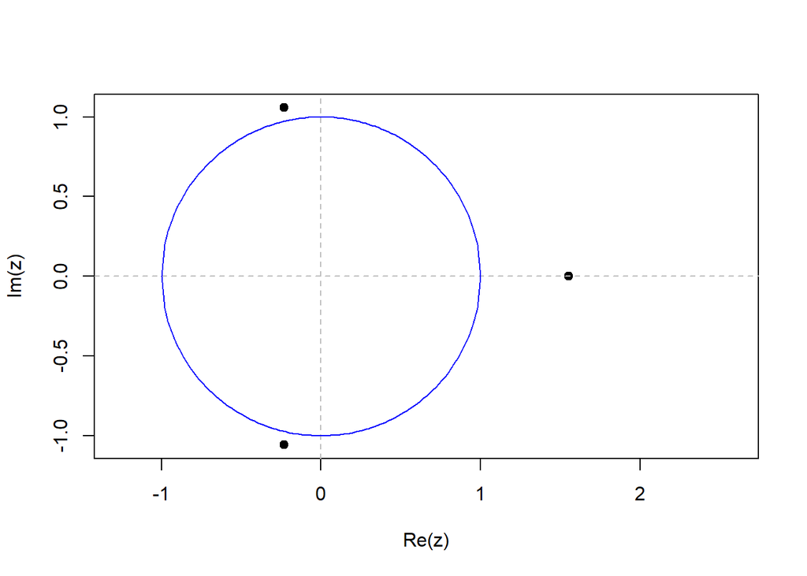

Všetky korene ležia mimo jednotkového kruhu. Proces je stacionárny.

### Proces $x_t = 0.8x_{t-1} + 0.3x_{t-2} + 0.2x_{t-3} + u_t$

```r
abs(polyroot(c(1,-0.8,-0.3,-0.2)))
```

```
## [1] 0.8387136 2.4416205 2.4416205
```

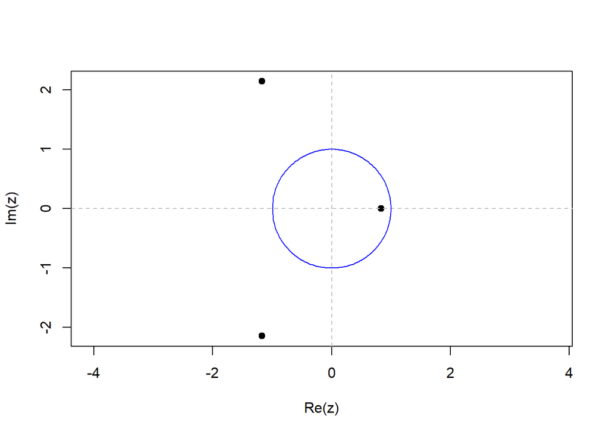

Jeden koreň leží vnútri jednotkového kruhu. Proces nie je stacionárny.

### Proces $x_t = 0.25 + 0.1 x_{t-1} + 0.2 x_{t-3} + u_t$

```r
abs(polyroot(c(1,-0.1,0,-0.2)))
```

```
## [1] 1.612620 1.760836 1.760836
```

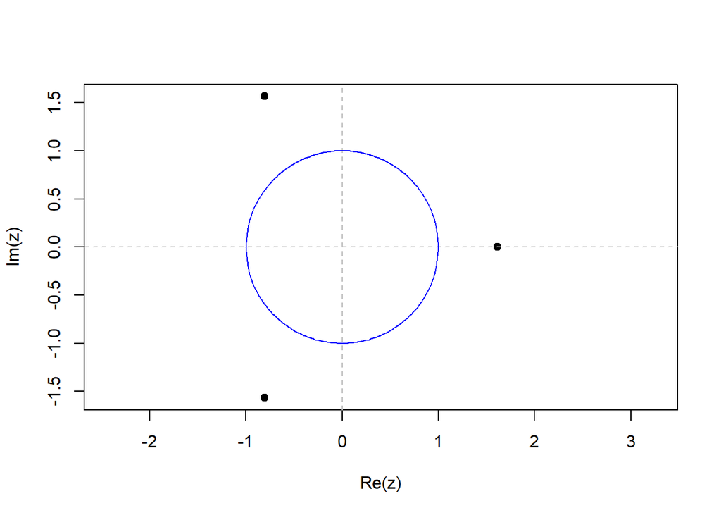

Všetky korene ležia mimo jednotkového kruhu. Proces je stacionárny.

# Príklad 4: Nájdenie príkladu procesu s danou vlastnosťou - Jedno z možných riešení

### Stacionárny AR(3) proces:

Všeobecný predpis AR(3) procesu je daný $x_t =\delta + \alpha_1 x_{t-1} + \alpha_2 x_{t-2} + \alpha_3 x_{t-3} + u_t$. (Ne)stacionarita nezávisí od konštantného člena, preto môžeme voliť $\delta=0$.

Idea: zvoliť koeficienty $\alpha_i$ blízke nule.

Napríklad proces $x_t = 0.1x_{t-1} + 0.1x_{t-2} + 0.1x_{t-3} + u_t.$

```r
abs(polyroot(c(1,-0.1,-0.1,-0.1)))
```

```
## [1] 1.73737 2.39913 2.39913
```

Všetky korene polynómu $1-0.1L-0.1L^2-0.1L^3$ sú v absolútnej hodnote väčšie ako 1 (t. j. ležia mimo jednotkového kruhu). Proces je naozaj stacionárny.

### Nestacionárny AR(4) proces:

Idea: Nech jeden z koreňov je rovný $L=\frac{1}{2} <1$. To zaručí, že proces bude nestacionárny. Teda napríklad proces daný $(1-2L)(1-\frac{1}{2}L)(1-\frac{1}{3}L)(1-\frac{1}{4}L)x_t = u_t$, resp. po úprave $x_t = \frac{37}{12} x_{t-1} - \frac{61}{24}x_{t-2} + \frac{19}{24} x_{t-3} - \frac{1}{12} x_{t-4} + u_t$.

Overenie:

```r
abs(polyroot(c(1,-37/12,61/24,-19/24,1/12)))
```

```
## [1] 0.5 2.0 3.0 4.0
```

Naozaj, jeden koreň je rovný $L=\frac{1}{2}$, preto proces nie je stacionárny.

### Stacionárny AR(2) proces, ktorého stredná hodnota je rovná 15:

Napríklad proces $x_t = 15 + 0.5 x_{t-1} - 0.5 x_{t-2} + u_t.$

Overenie stacionarity:

```r
abs(polyroot(c(1, -0.5, 0.5)))
```

```
## [1] 1.414214 1.414214
```

Oba korene polynómu $1-0.5L+0.5L^2$ sú v absolútnej hodnote väčšie ako 1 (t. j. ležia mimo jednotkovej kružnice). Proces je naozaj stacionárny.

Strednú hodnotu AR(2) procesu $x_t = \delta + \alpha_1 x_{t-1} + \alpha_2 x_{t-2} + u_t$ jednoducho vypočítame ako
$$\mathbb{E}(x_t) =
\frac{\delta}{1-\alpha_1 - \alpha_2}$$
.

V našom prípade skutočne dostávame
$$\mathbb{E}(x_t) = \frac{15}{1-0.5 -(-0.5)} = 15$$
.